# Описательная статистика

## Задание 3

Проверьте при помощи квантильного графика, подчиняются ли эти переменные нормальному распределению:

- Рост американских женщин (датасет `women`)
- Длина чашелистиков у ирисов (датасет `iris`)
- Число пойманных рысей в Канаде с 1821 по 1934г. (датасет `lynx`)

## Решение (3.1)

```r
data("women")
str(women)
```

```
'data.frame':   15 obs. of  2 variables:
 $ height: num  58 59 60 61 62 63 64 65 66 67 ...
 $ weight: num  115 117 120 123 126 129 132 135 139 142 ...
```

```r
qqPlot(women$height, id = FALSE)
```

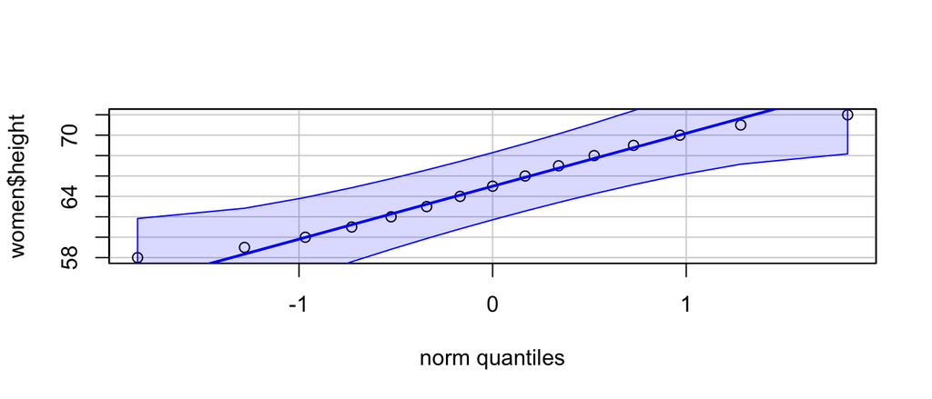

## Решение (3.2)

```r
data("iris")
str(iris)
```

```
'data.frame':   150 obs. of  5 variables:
 $ Sepal.Length: num  5.1 4.9 4.7 4.6 5 5.4 4.6 5 4.4 4.9 ...
 $ Sepal.Width : num  3.5 3 3.2 3.1 3.6 3.9 3.4 3.4 2.9 3.1 ...
 $ Petal.Length: num  1.4 1.4 1.3 1.5 1.4 1.7 1.4 1.5 1.4 1.5 ...
 $ Petal.Width : num  0.2 0.2 0.2 0.2 0.2 0.4 0.3 0.2 0.2 0.1 ...
 $ Species     : Factor w/ 3 levels "setosa","versicolor",..: 1 1 1 1 1 1 1 1 1 1 ...
```

```r
op <- par(mfrow = c(1, 2))
qqPlot(iris$Sepal.Length, id = FALSE)
hist(iris$Sepal.Length)
```

```r
par(op)
```

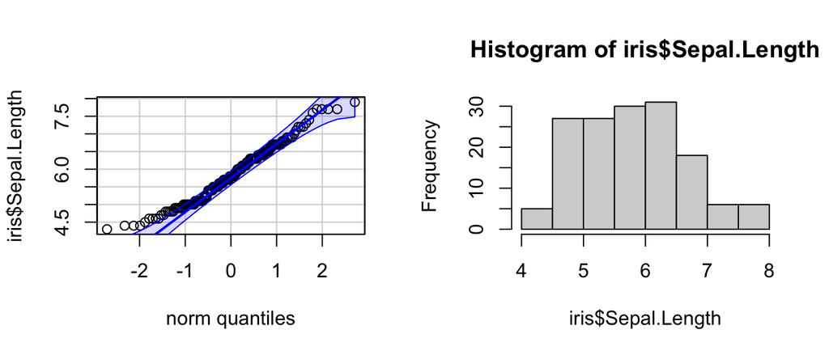

## Решение (3.3)

```r
data("lynx")
str(lynx)
```

```
 Time-Series [1:114] from 1821 to 1934: 269 321 585 871 1475 ...
```

```r
op <- par(mfrow = c(1, 2))
qqPlot(lynx, id = FALSE)
hist(lynx)
```

```r
par(op)
```

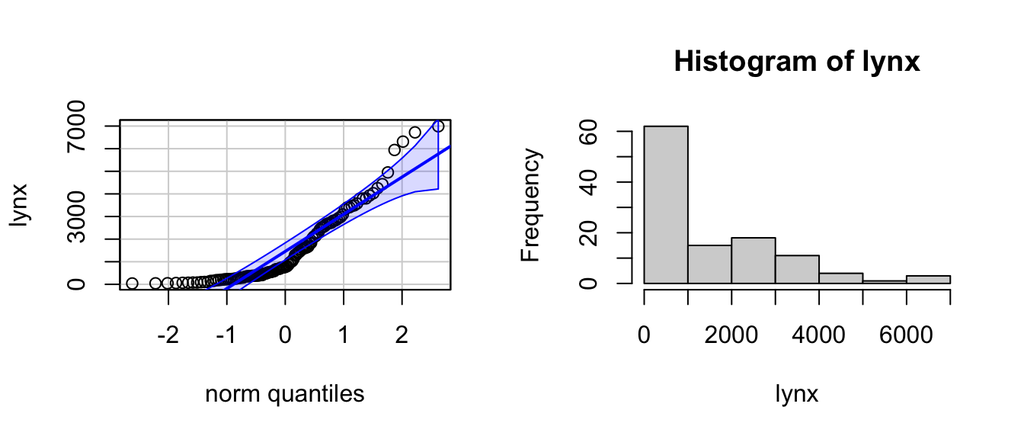

## ЧАСТЬ 7. Оценка вероятностей при помощи распределений

## Кривые распределений можно использовать для оценки вероятностей

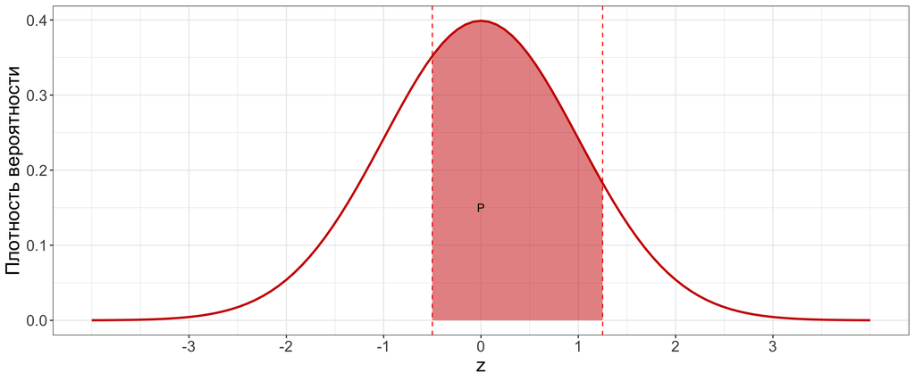

## Площадь под всей кривой распределения равна 1

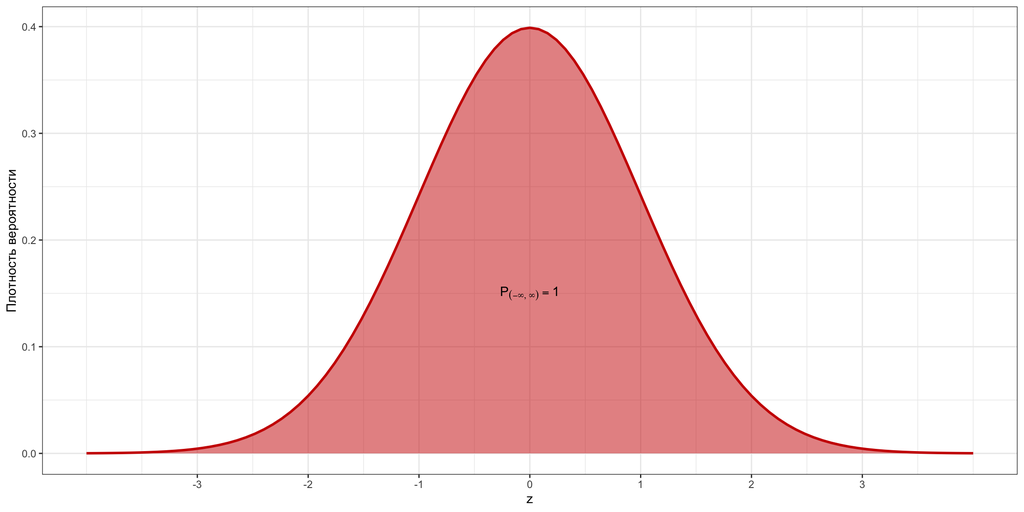

## Вероятность конкретного значения нельзя определить

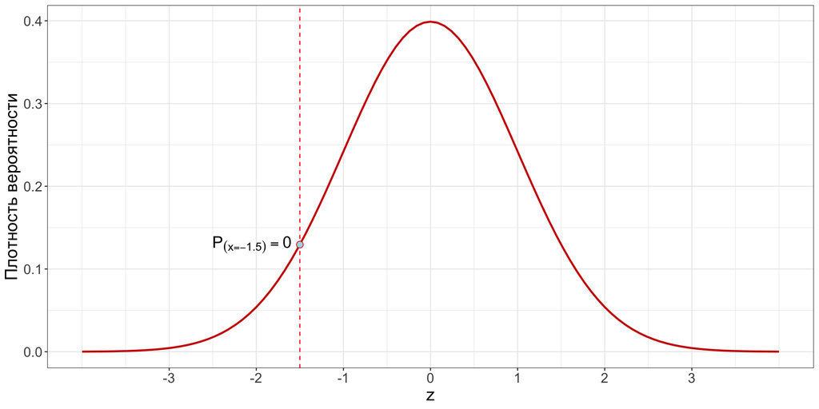

## Можно определить вероятность того, что значение будет меньше заданного

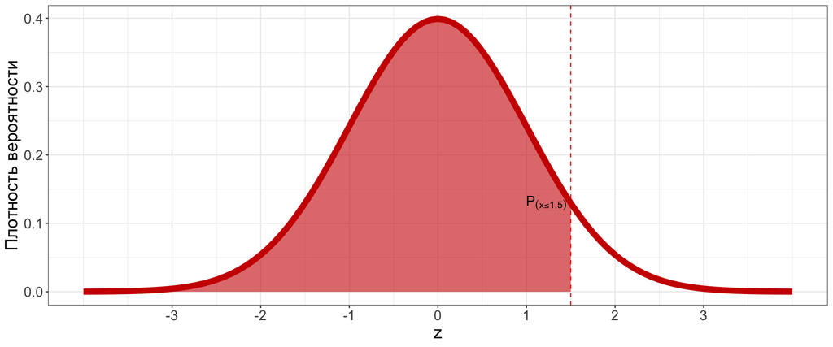

## Остальные площади легко найти при помощи простых арифметических действий с площадями

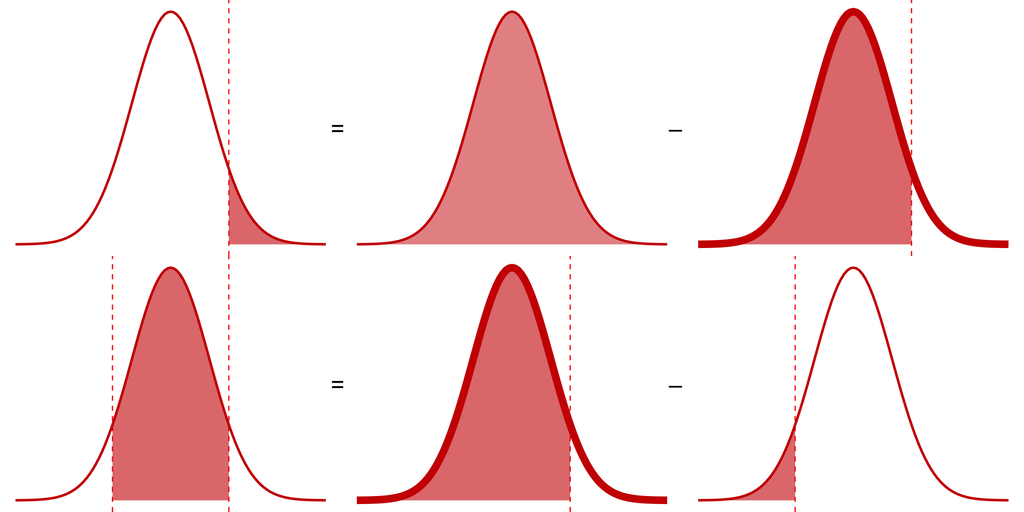

## Пример: Размеры улиток

В выборке улиток средний диаметр раковины 5 см со стандартным отклонением 1.5 см.

- Какова вероятность того, что случайно выбранная улитка окажется **меньше 3 см**?
- Какова вероятность того, что случайно выбранная улитка окажется **больше 6 см**?
- Какова доля улиток с размером раковины **в пределах 3–6 см**?

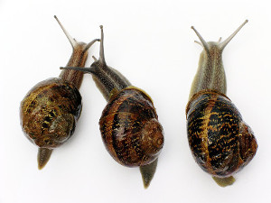

tres caracoles by Alberto Villen on Freeimages.com

## Вероятность встретить значение меньше заданного

В выборке улиток средний диаметр раковины 5 см со стандартным отклонением 1.5 см.

### Какова вероятность того, что случайно выбранная улитка окажется **меньше 3 см**?

```r
Z_1 <- (3 - 5) / 1.5
pnorm(q = Z_1)
```

```
[1] 0.09121122
```

```r
# или то же самое
pnorm(q = 3, mean = 5, sd = 1.5)
```

```
[1] 0.09121122
```

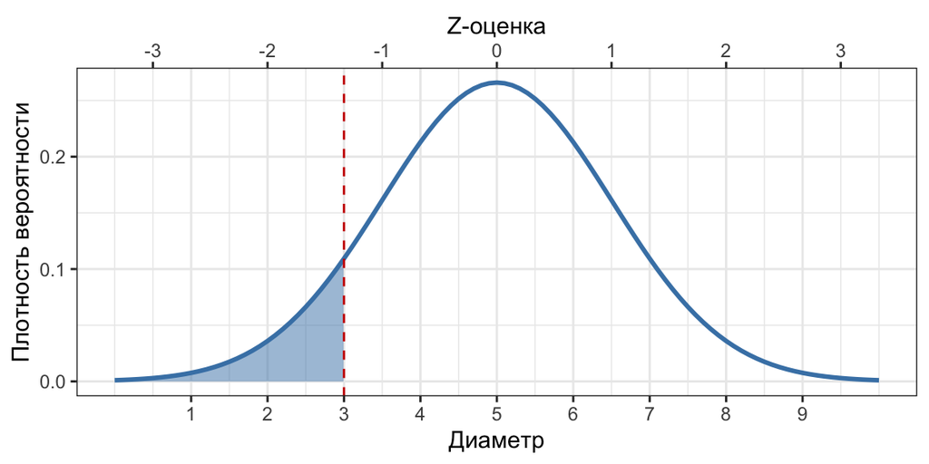

## Вероятность встретить значение больше заданного

В выборке улиток средний диаметр раковины 5 см со стандартным отклонением 1.5 см.

### Какова вероятность того, что случайно выбранная улитка окажется **больше 6 см**?

Мы умеем интегрировать только влево от выбранного значения, поэтому

- выясняем вероятность встретить значение меньше заданного $p$
- находим комплементарную вероятность $1 - p$

```r
1 - pnorm(q = 6, mean = 5, sd = 1.5)
```

```
[1] 0.2524925
```

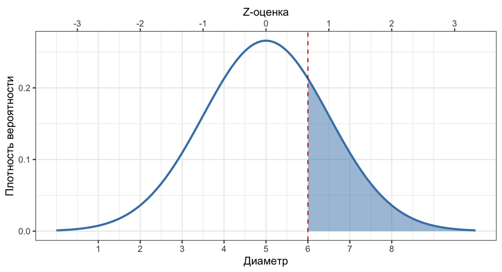

## Вероятность встретить значение в заданных пределах

В выборке улиток средний диаметр раковины 5 см со стандартным отклонением 1.5 см.

### Какова доля улиток с размером раковины **в пределах 3–6 см**?

```r
pnorm(q = 6, mean = 5, sd = 1.5) -
  pnorm(q = 3, mean = 5, sd = 1.5)
```

```
[1] 0.6562962
```

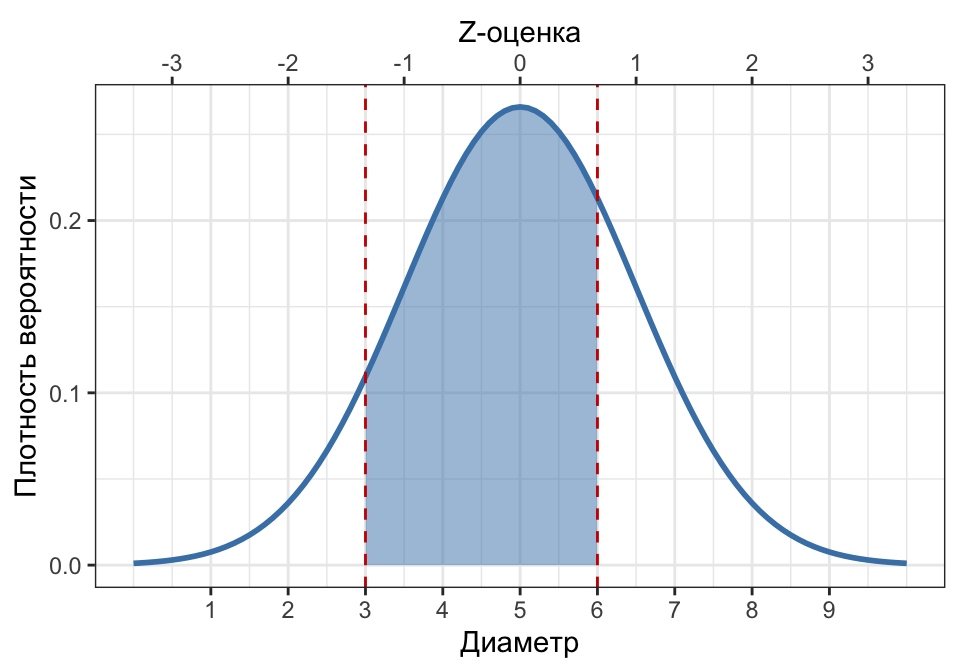

## Задание 4

Средний рост 18-летних мужчин в России 174.7 см со стандартным отклонением 6.65 см. В пилоты берут только людей с ростом от 160 до 190 см (по приказу Минтранса).

- Какова вероятность того, что случайно выбранный мужчина окажется **ниже 160 см**?
- Какова вероятность того, что случайно выбранный мужчина окажется **выше 190 см**?
- Какова доля мужчин, не подходящих по росту в пилоты, т.е. **ниже 160 и выше 190 см**?

## Решение (4.1)

Средний рост 18-летних мужчин в России 174.7 см со стандартным отклонением 6.65 см. В пилоты берут только с ростом от 160 до 190 см (по приказу Минтранса).

### Какова вероятность того, что случайно выбранный мужчина окажется **ниже 160 см**?

```r
Z_short <- (160 - 174.7) / 6.65
pnorm(q = Z_short)
```

```
[1] 0.01353433
```

```r
# или то же самое
pnorm(q = 160, mean = 174.7, sd = 6.65)
```

```
[1] 0.01353433
```

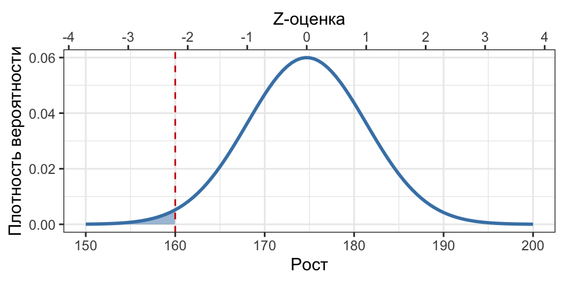

## Решение (4.2)

Средний рост 18-летних мужчин в России 174.7 см со стандартным отклонением 6.65 см. В пилоты берут только с ростом от 160 до 190 см (по приказу Минтранса).

### Какова вероятность того, что случайно выбранный мужчина окажется **выше 190 см**?

```r
1 - pnorm(q = 190, mean = 174.7, sd = 6.65)
```

```
[1] 0.01070283
```

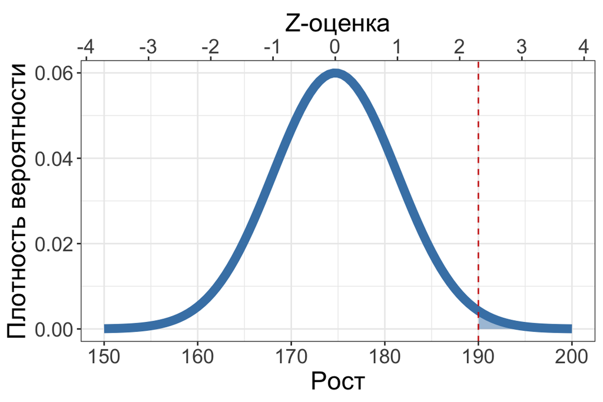

## Решение (4.3)

Средний рост 18-летних мужчин в России 174.7 см со стандартным отклонением 6.65 см. В пилоты берут только с ростом от 160 до 190 см (по приказу Минтранса).

### Какова доля мужчин, не подходящих по росту в пилоты, т.е. **ниже 160 и выше 190 см**?

```r
(1 - pnorm(q = 190, mean = 174.7, sd = 6.65)) +
  pnorm(q = 160, mean = 174.7, sd = 6.65)
```

```
[1] 0.02423716
```

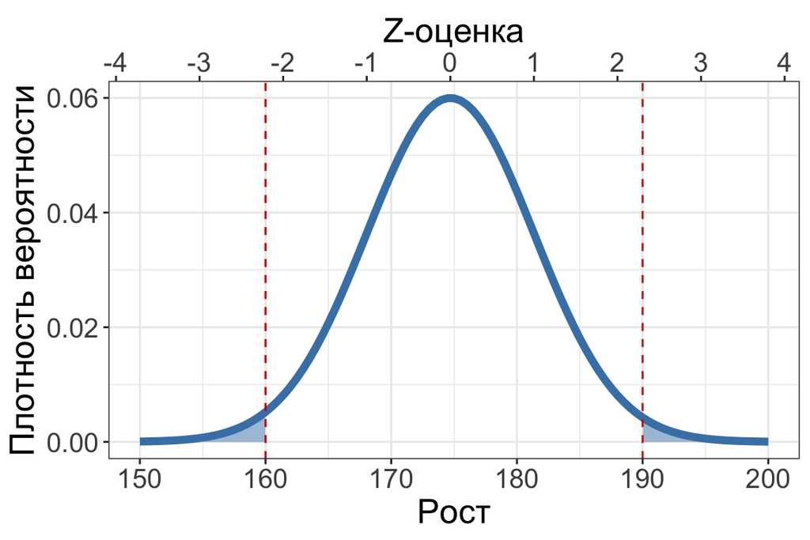

## Задание 5

Средний рост девушек в 16 лет — 162.2 см со стандартным отклонением 6.0 см.  
В пилоты берут только людей с ростом от 160 до 190 см (по приказу Минтранса).

Какой процент девушек подходит по росту в пилоты?

## Решение

Средний рост девушек в 16 лет — 162.2 см со стандартным отклонением 6.0 см.  
В пилоты берут только людей с ростом от 160 до 190 см (по приказу Минтранса).

### Какой процент девушек подходит по росту в пилоты?

```r
pnorm(q = 190, mean = 162.2, sd = 6.0) -
  pnorm(q = 160, mean = 162.2, sd = 6.0)
```

```
[1] 0.6430644
```

Только 64.3 % девушек пройдут в пилоты по росту.

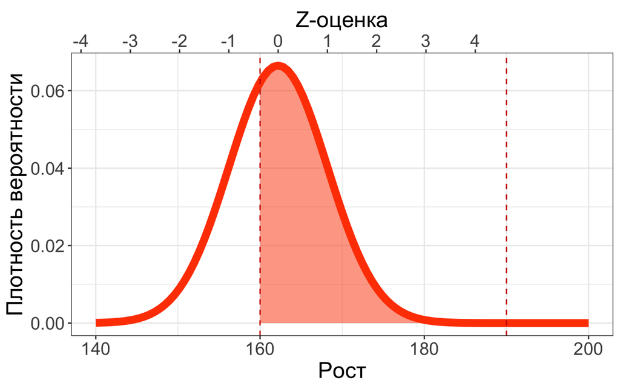

## Задание 6

Предположим, что вес новорожденных нормально распределен со средним значением 3500 г и стандартным отклонением 600 г.

- Какой процент детей рождается с весом больше 3200г.?
- Какой процент детей рождается с весом в пределах 2500-4500г.?

## Решение (1)

Предположим, что вес новорожденных нормально распределен со средним значением 3500 г и стандартным отклонением 600 г.

### Какой процент детей рождается с весом больше 3200г.?

```r
1 - pnorm(q = 3200, mean = 3500, sd = 600)
```

```
[1] 0.6914625
```

69.1 % детей рождается с весом больше 3200г.

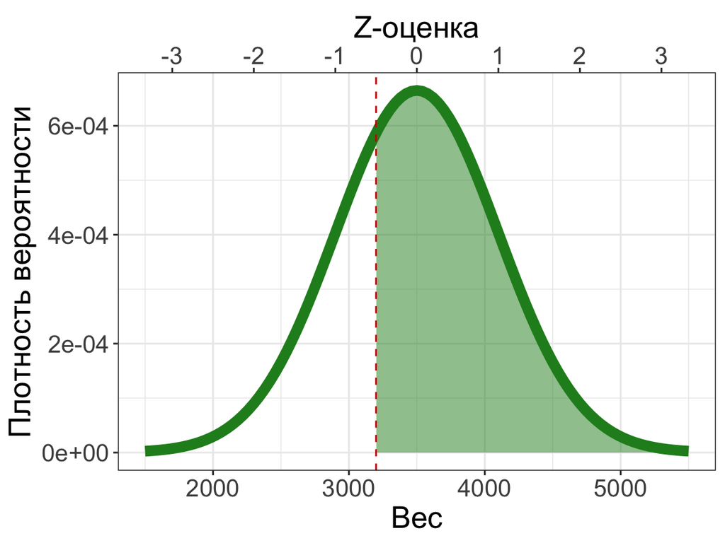

## Решение (2)

Предположим, что вес новорожденных нормально распределен со средним значением 3500 г и стандартным отклонением 600 г.

### Какой процент детей рождается с весом в пределах 2500-4500г.?

```r
pnorm(q = 4500, mean = 3500, sd = 600) - pnorm(q = 2500, mean = 3500, sd = 600)
```

```
[1] 0.9044193
```

90.4 % детей рождается с весом в пределах 2500-4500г.

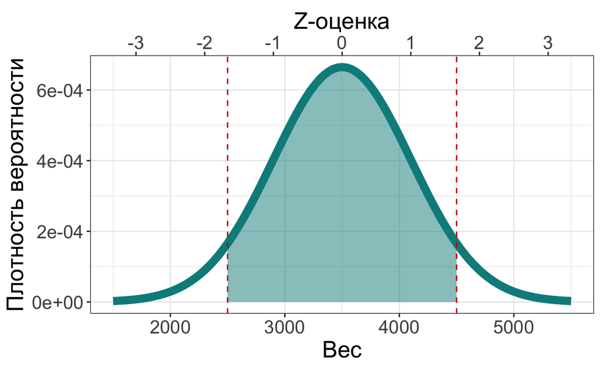

## Take-home messages

- Описательные статистики ходят только в связке.
- Выбирая между медианой и средним, учитывайте природу данных.
- Нормальное распределение $N(\mu,\sigma)$
- Стандартное нормальное распределение — $N(0, 1)$
- Стандартизация — $z = \frac{x - \mu} {\sigma}$
- Квантильный график — графический метод проверки формы распределения
- Вероятность попадания величины в любой интервал можно найти при помощи интегрирования